# Проект: Рабочие часы vs. Тревожные расстройства

Sveta Kuznetsova

12 03 2021

*В своем проекте я использовала данные о ряде стран в период с ~1990 по 2017 годы, в которых исследовала связь между средним количеством рабочих часов на человека и процентом населения с тревожными расстройствами.*

Датасеты взяты с сайта [Our World in Data](https://ourworldindata.org/):  
1. [Annual working hours per worker, various sources](https://ourworldindata.org/grapher/compare-sources-working-hours?tab=chart&stackMode=absolute&time=earliest..latest&region=World) - количество рабочих часов в год на человека, различные источники  
2. [Share of population with anxiety disorders](https://ourworldindata.org/grapher/share-with-anxiety-disorders?time=2017) - доля населения с тревожными расстройствами, Global Burden of Disease Study 2017 (GBD 2017)  
В объединенном виде эти датасеты выглядят вот так:

| Country | Year | Disorder | Hours |
| --- | --- | --- | --- |
| Argentina | 1990 | 6.165921 | 35.57692 |
| Argentina | 1991 | 6.174471 | 35.34540 |
| Argentina | 1992 | 6.182707 | 35.11538 |
| Argentina | 1993 | 6.190356 | 35.58342 |
| Argentina | 1994 | 6.197271 | 36.05769 |
| Argentina | 1995 | 6.203265 | 36.19156 |
| Argentina | 1996 | 6.207523 | 36.32592 |
| Argentina | 1997 | 6.210284 | 36.46079 |
| Argentina | 1998 | 6.212472 | 36.59615 |
| Argentina | 1999 | 6.214769 | 36.29394 |

[output cut: 1388 more lines]

```
##    Country               Year         Disorder         Hours
##  Length:1398        Min.   :1990   Min.   :2.023   Min.   :26.04
##  Class :character   1st Qu.:1997   1st Qu.:3.341   1st Qu.:32.83
##  Mode  :character   Median :2004   Median :4.574   Median :36.09
##                     Mean   :2004   Mean   :4.683   Mean   :36.68
##                     3rd Qu.:2011   3rd Qu.:5.724   3rd Qu.:40.56
##                     Max.   :2017   Max.   :8.967   Max.   :51.48
```

```
## [1] "Unique countries in dataset:  50"
```

## Гипотезы

### Первая гипотеза:

> *Количество рабочих часов коррелирует с уровнем тревожности среди населения (а именно, сказывается на нем негативно)*

*Plot 1: динамика изменения количества рабочих часов и уровня тревожности среди населения с 1990 по 2017 гг. по странам*

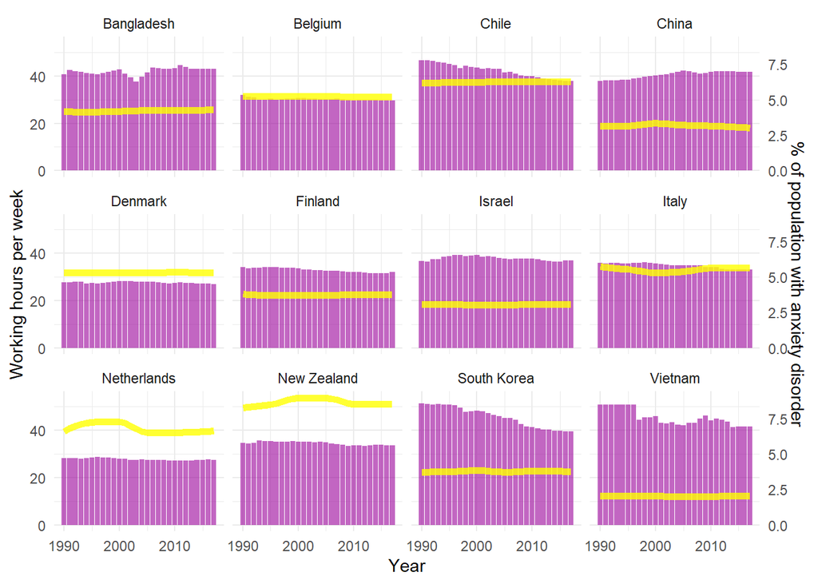

Проверим эту гипотезу корреляционным тестом Пирсена

```r
cor.test(hd$Hours, hd$Disorder)
```

```
##
##  Pearson's product-moment correlation
##
## data:  hd$Hours and hd$Disorder
## t = -30.035, df = 1396, p-value < 2.2e-16
## alternative hypothesis: true correlation is not equal to 0
## 95 percent confidence interval:
##  -0.6573694 -0.5936055
## sample estimates:
##        cor
## -0.6265347
```

А также Спирмена и Кэнделла

```r
cor.test(hd$Hours, hd$Disorder, method = "spearman")
```

```
##
##  Spearman's rank correlation rho
##
## data:  hd$Hours and hd$Disorder
## S = 745942198, p-value < 2.2e-16
## alternative hypothesis: true rho is not equal to 0
## sample estimates:
##        rho
## -0.6380801
```

```r
cor.test(hd$Hours, hd$Disorder, method = "kendall")
```

```
##
##  Kendall's rank correlation tau
##
## data:  hd$Hours and hd$Disorder
## z = -24.287, p-value < 2.2e-16
## alternative hypothesis: true tau is not equal to 0
## sample estimates:
##        tau
## -0.4335987
```

И составим корреляционную матрицу

```r
print(hd %>% select(Disorder, Hours, Year) %>% psych::corr.test(adjust = "bonferroni"), digits=4)
```

```
## Call:psych::corr.test(x = ., adjust = "bonferroni")
## Correlation matrix
##          Disorder   Hours    Year
## Disorder   1.0000 -0.6265  0.0082
## Hours     -0.6265  1.0000 -0.1272
## Year       0.0082 -0.1272  1.0000
## Sample Size
## [1] 1398
## Probability values (Entries above the diagonal are adjusted for multiple tests.)
##          Disorder Hours Year
## Disorder   0.0000     0    1
## Hours      0.0000     0    0
## Year       0.7594     0    0
##
##  To see confidence intervals of the correlations, print with the short=FALSE option
```

*Plot 2: Корреляция между показателями рабочих часов и процентом населения с тревожными расстройствами по всей выборке*

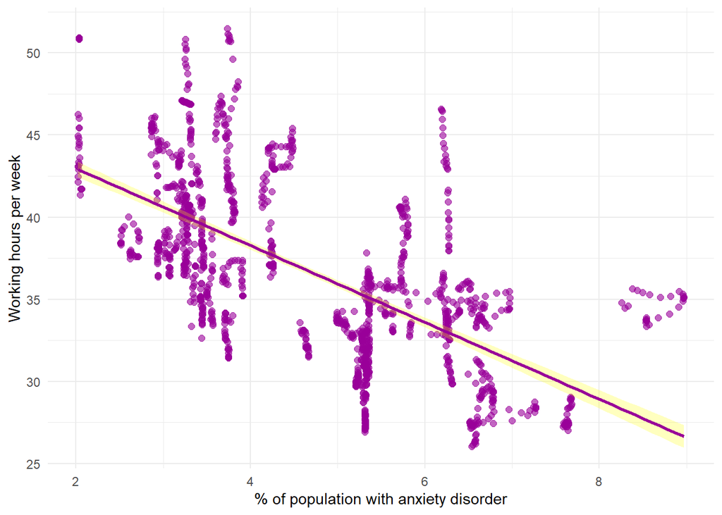

### Вторая гипотеза:

> В целом по странам коэффициент (hours x disorder) снизился в период с 1990 по 2017 годы

*Plot 3: Распределение стран на плоскости часы/расстройства за все годы сразу, с динамикой изменения*

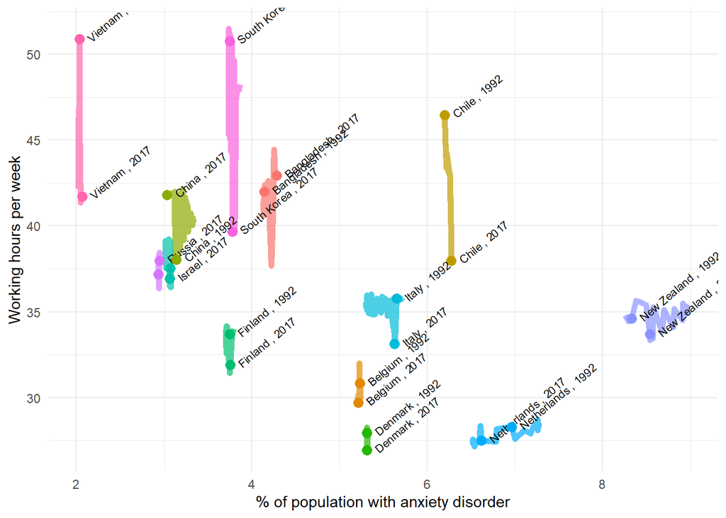

Проверим эту гипотезу двухвыборочным зависимым t-тестом

```r
t.test(hdratio$`1992`, hdratio$`2017`, paired = TRUE, alternative = "two.sided")
```

```
##
##  Paired t-test
##
## data:  hdratio$`1992` and hdratio$`2017`
## t = 4.4321, df = 49, p-value = 5.251e-05
## alternative hypothesis: true difference in means is not equal to 0
## 95 percent confidence interval:
##   4.307313 11.453433
## sample estimates:
## mean of the differences
##                7.880373
```

*Plot 4: Визуализация изменения коэффициента (hours x disorder) в странах с 1992 по 2017 годы*

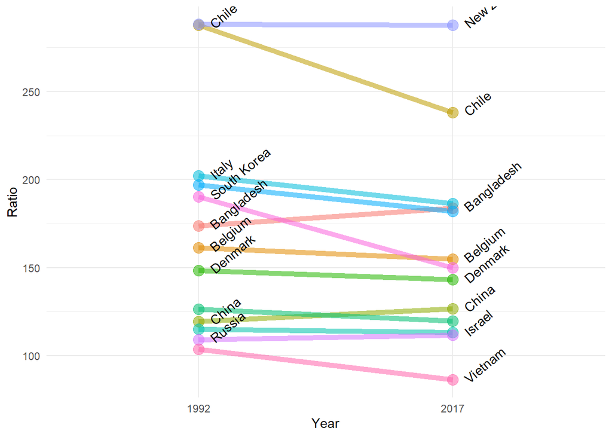